# Next Word Prediction - Exploratory Analysis

Ash Chakraborty

March 15, 2016

# Overview

[Complete Code May Be Viewed in this Github Location](https://github.com/ashirwad08/typed-word-predictor/blob/master/NextWordPredictor_Exploration.Rmd)

As engagement with mobile devices becomes second nature for us, we’re experiencing more effective means of capturing the intended content of communication on these devices, *viz.* dynamic spell-checkers, swipe-able keyboards, and **next word predictors**. The aim of this analysis is to lay the foundations for a word prediction app. that may be used in a similar vain to that of [Swiftkey’s](https://swiftkey.com/en/company) next word prediction feature in their keyboard application.

Specifically, this report’s objectives are the following:  
* Load and clean the input datasets required to train the prediction model,  
* Explore summary statistics and analyze the dataset for other revelations,  
* Layout a blueprint for the prediction algorithm and the prediction application.

# Load and PreProcess Data

I first read in the text files and unpack them into what turns out to be very large Corpora containing the following corpus types:

- Blog Text: A collection of blog posts.
- News Text: A collection of news articles.
- Twitter Tweets: A collection of Tweets.

Before we can collect some summary statistics for each, some preliminary cleanup is needed. Specifically:

## Word Tokenizing and Normalization

Each of the corpus(es?) in the Corpora are stored in three character vectors in the “corp” logical object. In order to get a better understanding of each, it is necessary to first perform the following pre-processing steps:

- Force Lowercase
- Remove Numbers
- Remove Punctuation Characters: Attempt to remove special characters that result in emoticons, that are apostrophes, periods, commas, semicolons, excessive punctuation. *Exceptions:* Preserve the octothorpe “#” character in the Tweets corpus to analyze significance of tweeted hashtag context.
- Strip Unnecessary Whitespaces

### Document Summaries

The following table shows the approximate token counts for each document type, after the steps above:

| document.source | size_MB | lines | tokens | types |
| --- | --- | --- | --- | --- |
| Blogs | 239 | 899,288 | 36,818,677 | 874,912 |
| News | 239 | 1,010,242 | 33,476,199 | 890,333 |
| Twitter | 289 | 2,360,148 | 29,421,345 | 1,535,213 |

### Stop Words

To get a better type grouping, and for better frequency analysis, we get rid of common stop words such as `were, ours, doesn't, aren't, at, isn't, that, theirs, above, out`, etc.

### Stemming

Finally, we chop the word *affixes* from their *stems* to improve type grouping and frequency analysis.

### Lemmatization

We choose not to perform any lemmatization on account of the rather generic problem domain.

## Final Document Summary

After all our pre-processing is complete, we see the following document summary:

| document.source | size_MB | lines | tokens | types |
| --- | --- | --- | --- | --- |
| Blogs | 177 | 899,288 | 19,359,446 | 617,781 |
| News | 189 | 1,010,242 | 19,657,775 | 648,259 |
| Twitter | 248 | 2,360,148 | 17,464,307 | 1,250,967 |

# More Summary Statistics

On account of the Corpora being so large, I’ll have to explore stats on a random sample. I’ll create a “sub” corpora, sampling 2% of the original corpus.

## Document Term Matrix

First, generate the sub-corpora, then the document term matrix, which will give us the frequency of terms. The 20 most frequent terms in the this sample corpus are:

| will | 6574 |
| --- | --- |
| one | 6086 |
| like | 6059 |
| just | 6037 |
| get | 5987 |
| said | 5958 |
| time | 5234 |
| can | 5153 |
| day | 4466 |
| year | 4382 |
| make | 4079 |
| love | 4002 |
| new | 3882 |
| know | 3718 |
| good | 3677 |
| now | 3633 |
| dont | 3548 |
| work | 3542 |
| say | 3316 |
| want | 3203 |

## Summary Plots

50 of the most frequently occuring words in the sample:

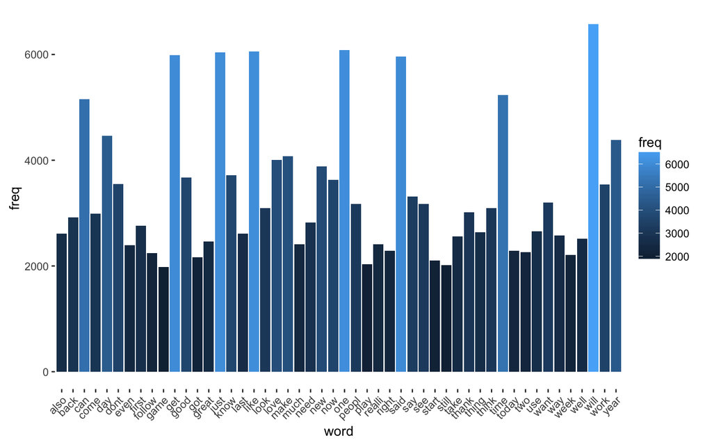

Finally, here’s a wordcloud of words that occur at least 100 times or more in the sample corpora:

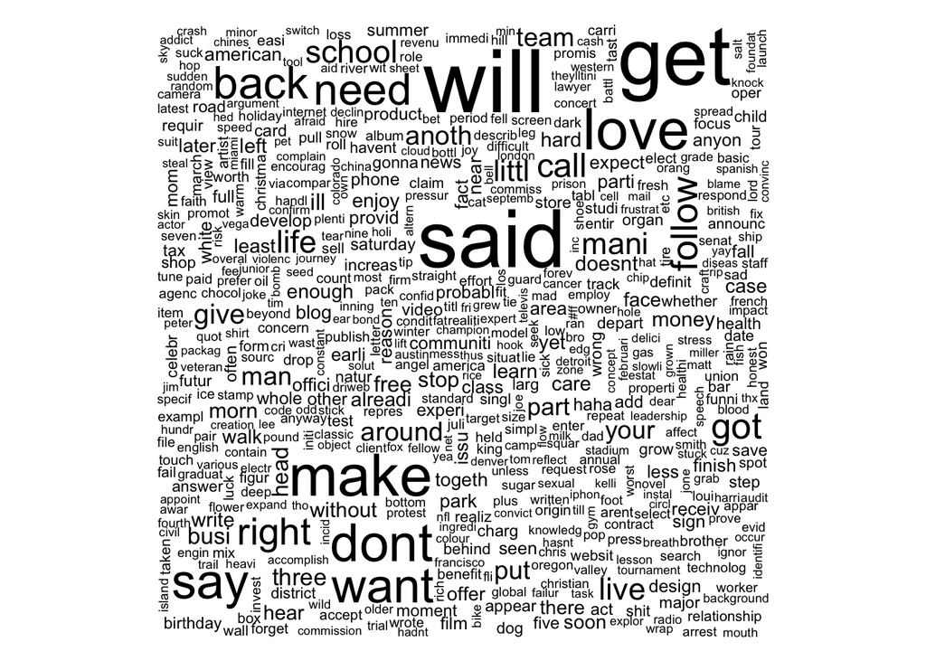

# Prediction Application

So far I’ve settled on using a multi-gram Bayesian model to act as the predictor for the word prediction application. I’ll experiment with tri-grams and quad-grams with the Markov assumption in place. Basically, the prediction model will be computing something like: *P(next word | bi-gram/tri-gram/etc.)*.

*End of Report*

[Complete Code May Be Viewed in this Github Location](https://github.com/ashirwad08/typed-word-predictor/blob/master/NextWordPredictor_Exploration.Rmd)